# Week 5 - Dimensionality reduction techniques

## 1 - data

Our dataset today contains country-level data concerning variables related to human development and gender equality. The variables include: * education: eduRatio (proportion of women vs. men with secondary education) and eduExp (expected years of education) * participation in society: labourRatio (proportion of women vs. men in labour force) and parliament (proportion of women in parliament) * health: lifeExp_birth (life expectancy at birth), maternalMort (maternal mortality rate) and adolBirth (adolescent birth rate) * wealth: gni (Gross National Income)

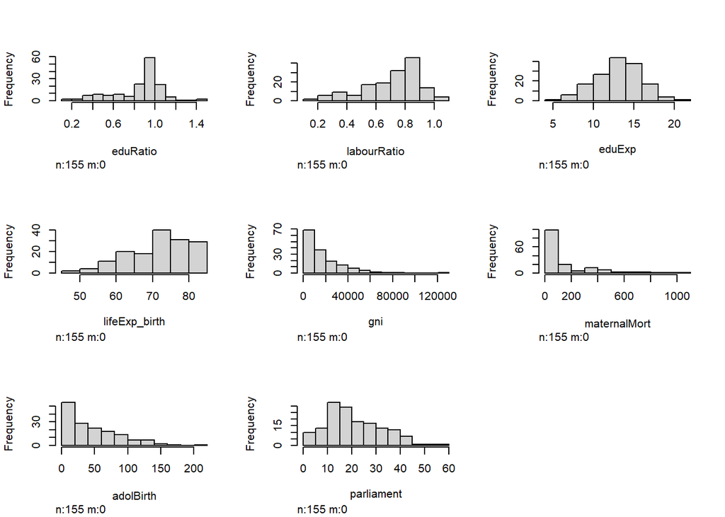

```r
library(ggplot2)
library(GGally)
library(corrplot)
library(Hmisc)
human <- read.table("data/human.csv")
hist.data.frame(human, nclass =10)
```

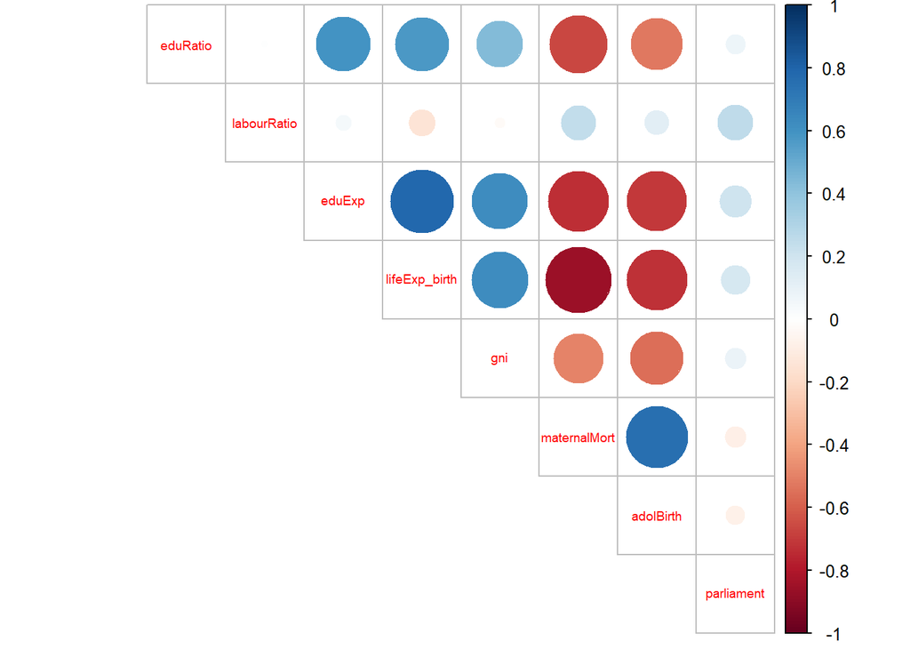

```r
corr <- cor(human)
corrplot(corr, method="circle", type="upper", tl.pos="d", tl.cex = 0.6)
```

```r
summary(human)
```

```
##     eduRatio       labourRatio         eduExp      lifeExp_birth
##  Min.   :0.1717   Min.   :0.1857   Min.   : 5.40   Min.   :49.00
##  1st Qu.:0.7264   1st Qu.:0.5984   1st Qu.:11.25   1st Qu.:66.30
##  Median :0.9375   Median :0.7535   Median :13.50   Median :74.20
##  Mean   :0.8529   Mean   :0.7074   Mean   :13.18   Mean   :71.65
##  3rd Qu.:0.9968   3rd Qu.:0.8535   3rd Qu.:15.20   3rd Qu.:77.25
##  Max.   :1.4967   Max.   :1.0380   Max.   :20.20   Max.   :83.50
##       gni          maternalMort      adolBirth        parliament
##  Min.   :   581   Min.   :   1.0   Min.   :  0.60   Min.   : 0.00
##  1st Qu.:  4198   1st Qu.:  11.5   1st Qu.: 12.65   1st Qu.:12.40
##  Median : 12040   Median :  49.0   Median : 33.60   Median :19.30
##  Mean   : 17628   Mean   : 149.1   Mean   : 47.16   Mean   :20.91
##  3rd Qu.: 24512   3rd Qu.: 190.0   3rd Qu.: 71.95   3rd Qu.:27.95
##  Max.   :123124   Max.   :1100.0   Max.   :204.80   Max.   :57.50
```

Most variables in the dataset are skewed toward one end or the other meaning that in most countries of the world for example maternal mortality is rare but then in a small number of countries it is alarmingly high. Ratios describing the proportion of women in different aspects of society are more evenly distributed although still with rather long tails. This means that for example labour ratio is somewhat normally distributed but with a long tail towards less women in the workforce.

Many of these variables also correlate strongly with each other, particularly health and education variables. Parliament and labour correlate little with any of the other variables.

## 2 - PCA

This is a lot of data to handle so let’s see if we can make that a bit easier with principal component analysis (PCA).

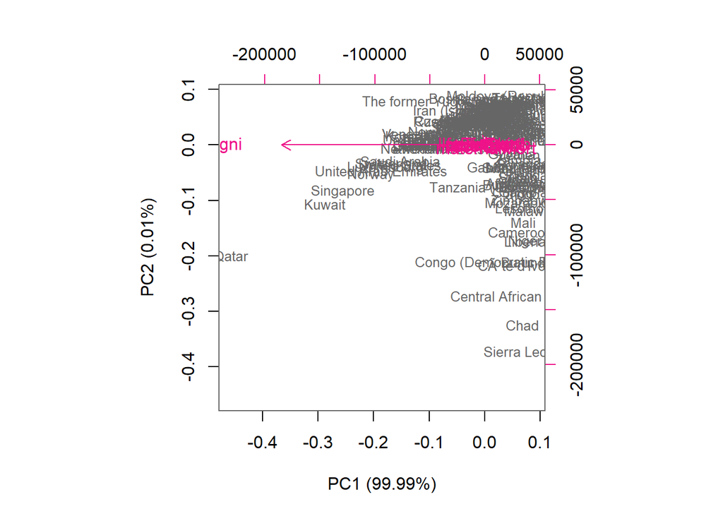

PCA with an unscaled dataset. All variables seem to belong to one dimension with GNI correlating negatively with the rest.

```r
#Calculate PCA
pca_human <- prcomp(human)
#Create summary and check variance of each PC
s <- summary(pca_human)
pca_pr <- 100 * round(1*s$importance[2, ], digits = 5)
#plot results
pc_lab <- paste0(names(pca_pr), " (", pca_pr, "%)")
# draw a biplot
biplot(pca_human, cex = c(0.8, 1), col = c("grey40", "deeppink2"), xlab = pc_lab[1], ylab = pc_lab[2])
```

```r
pc_lab
```

```
## [1] "PC1 (99.99%)" "PC2 (0.01%)"  "PC3 (0%)"     "PC4 (0%)"     "PC5 (0%)"
## [6] "PC6 (0%)"     "PC7 (0%)"     "PC8 (0%)"
```

## 3 and 4 - PCA with a scaled dataset and personal interpretations

Let’s see if the results get any more interesting with a scaled dataset.

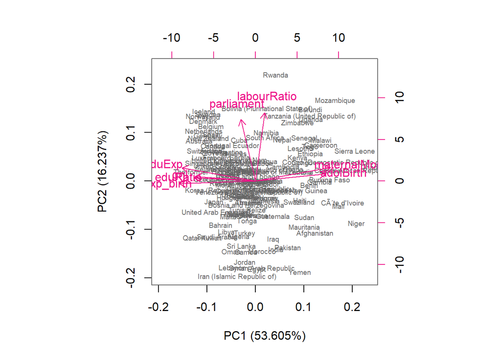

```r
#Scaling
human_std <- scale(human)
#Calculate PCA
pca_human <- prcomp(human_std)
#Create summary and check variance of each PC
s <- summary(pca_human)
pca_pr <- 100 * round(1*s$importance [2, ], digits = 5)
#plot results
pc_lab <- paste0(names(pca_pr), " (", pca_pr, "%)")
# draw a biplot
biplot(pca_human, cex = c(0.6, 1), col = c("grey40", "deeppink2"), xlab = pc_lab[1], ylab = pc_lab[2])
```

```r
pc_lab
```

```
## [1] "PC1 (53.605%)" "PC2 (16.237%)" "PC3 (9.571%)"  "PC4 (7.583%)"
## [5] "PC5 (5.477%)"  "PC6 (3.595%)"  "PC7 (2.634%)"  "PC8 (1.298%)"
```

Much more interesting. Now that the considerably large values of GNI don’t mess up the whole analysis, there seems to be more dimensionality in the data. Education and health related variables form the first dimension with lower education, GNI and life expectancy meaning higher maternal mortality rates and adolescent birth rates. The second dimension is formed by proportion of women in labour force and parliament. In other words, variables included in the Human Development Index form the first dimension and variables included in the Gender Inequality Index the second dimension meaning that these two indices do indeed measure different societal phenomena. Interestingly it would seem that HDI describes a one-dimensional phenomena since all variables related to it are along the same dimension - either a country has educated, rich people with relatively little health problems or everything’s going bad (a gross oversimplification of course). GII instead seems to have more dimensionality - women’s participation in labour and politics form one dimension which doesn’t necessarily correlate that much with their health. One interpretation of this could be that some countries may have managed to improve women’s health (at least when it comes to reproducive aspects of it) but that doesn’t automatically mean women have access to political or financial power.

## 5 - MCA

Finally, we’ll use a different dataset to get accustomed to MCA - Multiple Correspondence Analysis, meant to be used with factor datasets. The dataset shown below contains information about tea-drinking habits, a somewhat more cozy subject than human development.

```r
library(FactoMineR)
library(dplyr)
library(tidyr)
#Let's download and examine the dataset
data(tea)
str(tea)
```

```
## 'data.frame':    300 obs. of  36 variables:
##  $ breakfast       : Factor w/ 2 levels "breakfast","Not.breakfast": 1 1 2 2 1 2 1 2 1 1 ...
##  $ tea.time        : Factor w/ 2 levels "Not.tea time",..: 1 1 2 1 1 1 2 2 2 1 ...
##  $ evening         : Factor w/ 2 levels "evening","Not.evening": 2 2 1 2 1 2 2 1 2 1 ...
##  $ lunch           : Factor w/ 2 levels "lunch","Not.lunch": 2 2 2 2 2 2 2 2 2 2 ...
##  $ dinner          : Factor w/ 2 levels "dinner","Not.dinner": 2 2 1 1 2 1 2 2 2 2 ...
##  $ always          : Factor w/ 2 levels "always","Not.always": 2 2 2 2 1 2 2 2 2 2 ...
##  $ home            : Factor w/ 2 levels "home","Not.home": 1 1 1 1 1 1 1 1 1 1 ...
##  $ work            : Factor w/ 2 levels "Not.work","work": 1 1 2 1 1 1 1 1 1 1 ...
##  $ tearoom         : Factor w/ 2 levels "Not.tearoom",..: 1 1 1 1 1 1 1 1 1 2 ...
##  $ friends         : Factor w/ 2 levels "friends","Not.friends": 2 2 1 2 2 2 1 2 2 2 ...
##  $ resto           : Factor w/ 2 levels "Not.resto","resto": 1 1 2 1 1 1 1 1 1 1 ...
##  $ pub             : Factor w/ 2 levels "Not.pub","pub": 1 1 1 1 1 1 1 1 1 1 ...
##  $ Tea             : Factor w/ 3 levels "black","Earl Grey",..: 1 1 2 2 2 2 2 1 2 1 ...
##  $ How             : Factor w/ 4 levels "alone","lemon",..: 1 3 1 1 1 1 1 3 3 1 ...
```

[output cut: 22 more lines]

```r
dim(tea)
```

```
## [1] 300  36
```

```r
#time_columns <- c("breakfast", "tea.time", "evening", "lunch", "dinner", "always")

# select the 'keep_columns' to create a new dataset
#tea_time <- select(tea, one_of(time_columns))
#gather(tea_time) %>% ggplot(aes(value)) + geom_bar() + theme(axis.text.x = element_text(angle = 45, hjust = 1, size = 8)) + facet_wrap("key", scales = "free")

where_col <- c("home", "work", "tearoom" ,"friends", "resto", "pub")
tea_place <- select(tea, one_of(where_col))
#gather(tea_place) %>% ggplot(aes(value)) + geom_bar() + theme(axis.text.x = element_text(angle = 45, hjust = 1, size = 8)) + facet_wrap("key", scales = "free")

how_col <- c("How", "sugar", "how", "price", "where", "frequency")
tea_how <- select(tea, one_of(how_col))
#gather(tea_how) %>% ggplot(aes(value)) + geom_bar() + theme(axis.text.x = element_text(angle = 45, hjust = 1, size = 8)) + facet_wrap("key", scales = "free")

people_col <- c("sex" ,"SPC" ,"Sport", "age_Q")
tea_people <- select(tea, one_of(people_col))
#gather(tea_people) %>% ggplot(aes(value)) + geom_bar() + theme(axis.text.x = element_text(angle = 45, hjust = 1, size = 8)) + facet_wrap("key", scales = "free")

why_col <- c("escape.exoticism", "spirituality", "healthy", "diuretic", "friendliness", "iron.absorption", "feminine", "sophisticated", "slimming", "exciting", "relaxing" ,"effect.on.health")
tea_why <- select(tea, one_of(why_col))
#gather(tea_why) %>% ggplot(aes(value)) + geom_bar() + theme(axis.text.x = element_text(angle = 45, hjust = 1, size = 8)) + facet_wrap("key", scales = "free")
```

Oh boy, that’s a lot of data. Let’s focus on how people drink tea, that seems like fun.

```r
mca <- MCA(tea_how, graph = FALSE)
summary(mca)
```

```
##
## Call:
## MCA(X = tea_how, graph = FALSE)
##
##
## Eigenvalues
##                        Dim.1   Dim.2   Dim.3   Dim.4   Dim.5   Dim.6   Dim.7
## Variance               0.356   0.287   0.209   0.204   0.176   0.172   0.170
## % of var.             13.368  10.777   7.839   7.646   6.585   6.461   6.380
## Cumulative % of var.  13.368  24.145  31.984  39.630  46.215  52.676  59.056
##                        Dim.8   Dim.9  Dim.10  Dim.11  Dim.12  Dim.13  Dim.14
## Variance               0.163   0.156   0.146   0.140   0.127   0.120   0.094
## % of var.              6.115   5.864   5.490   5.254   4.761   4.518   3.515
## Cumulative % of var.  65.171  71.034  76.524  81.778  86.540  91.058  94.573
##                       Dim.15  Dim.16
## Variance               0.087   0.058
## % of var.              3.268   2.158
## Cumulative % of var.  97.842 100.000
##
## Individuals (the 10 first)
##                       Dim.1    ctr   cos2    Dim.2    ctr   cos2    Dim.3
## 1                  | -0.799  0.597  0.132 |  0.430  0.215  0.038 |  0.821
## 2                  | -0.438  0.179  0.117 | -0.130  0.020  0.010 |  0.218
## 3                  | -0.152  0.021  0.024 | -0.204  0.048  0.043 | -0.627
## 4                  | -0.464  0.201  0.191 |  0.029  0.001  0.001 |  0.022
## 5                  | -0.152  0.021  0.024 | -0.204  0.048  0.043 | -0.627
## 6                  | -0.635  0.377  0.133 |  0.289  0.097  0.027 | -0.119
## 7                  | -0.154  0.022  0.011 | -0.188  0.041  0.017 | -0.541
## 8                  | -0.423  0.167  0.079 |  0.071  0.006  0.002 |  0.033
## 9                  |  0.808  0.610  0.249 | -0.563  0.368  0.121 |  0.332
## 10                 |  0.902  0.760  0.389 | -0.508  0.299  0.124 | -0.201
##                       ctr   cos2
## 1                   1.074  0.139 |
## 2                   0.076  0.029 |
## 3                   0.627  0.404 |
## 4                   0.001  0.000 |
## 5                   0.627  0.404 |
## 6                   0.022  0.005 |
## 7                   0.467  0.143 |
## 8                   0.002  0.000 |
```

[output cut: 20 more lines]

```
## No.sugar            -2.897 |  -0.447   8.215   0.213  -7.984 |
## sugar                2.897 |   0.477   8.781   0.213   7.984 |
## tea bag              3.815 |  -0.033   0.050   0.001  -0.658 |
## tea bag+unpackaged -10.616 |   0.153   0.586   0.011   1.789 |
## unpackaged           9.337 |  -0.243   0.564   0.008  -1.550 |
## p_branded            1.598 |  -0.302   2.305   0.042  -3.556 |
##
## Categorical variables (eta2)
##                      Dim.1 Dim.2 Dim.3
## How                | 0.068 0.094 0.577 |
## sugar              | 0.046 0.028 0.213 |
## how                | 0.608 0.536 0.015 |
## price              | 0.594 0.299 0.222 |
## where              | 0.710 0.632 0.093 |
## frequency          | 0.112 0.135 0.134 |
```

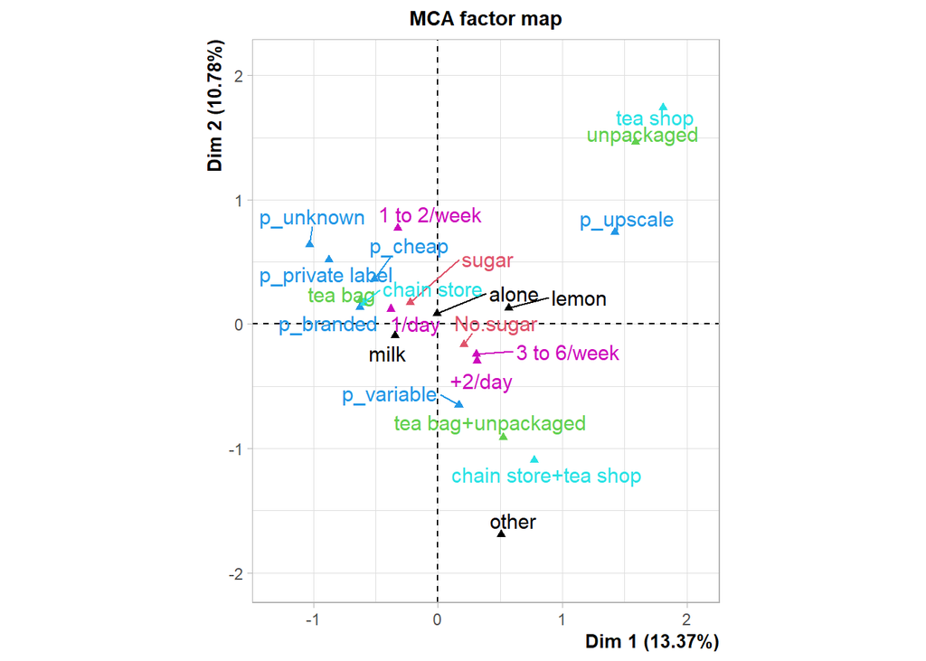

```r
plot(mca, invisible=c("ind"), habillage = "quali")
```

It seems there is at least some dimensionality in the data. Unpackaged, fancy tea people vs. cheap bag-tea-people vs. somewhere in the middle seem to form specific groups.